# Responsi 5 MPDW

Arfiah Kania Sektiaruni

2023-09-21

## Packages

```r
library(ggplot2)
library(tsibble)
library(tseries)
library(MASS)
```

## Impor Data

```r
datalat5 <- rio::import("https://raw.githubusercontent.com/afhkaniase/praktikum-mpdw/main/Data/Data%20Temperatur%20Portugal%202023.csv")
str(datalat5)
```

```
## 'data.frame':    212 obs. of  2 variables:
##  $ Periode    : int  1 2 3 4 5 6 7 8 9 10 ...
##  $ Temperature: num  15.9 11.1 10.2 9.9 9.9 11 14.8 16.2 15.4 14.4 ...
```

```r
head(datalat5)
```

```
##   Periode Temperature
## 1       1        15.9
## 2       2        11.1
## 3       3        10.2
## 4       4         9.9
## 5       5         9.9
## 6       6        11.0
```

## Mengubah data agar terbaca sebagai data deret waktu dengan fungsi `ts()` .

```r
datalat5.ts <- ts(datalat5$Temperature)
datalat5.ts
```

```
## Time Series:
## Start = 1
## End = 212
## Frequency = 1
##   [1] 15.9 11.1 10.2  9.9  9.9 11.0 14.8 16.2 15.4 14.4 13.9 11.5 11.6 10.5 11.6
##  [16] 12.9 12.8  9.4  9.9 14.0 13.7 10.2  8.2  8.3  7.6  8.8  9.3  8.3  7.5  7.5
##  [31]  8.5  8.3  8.3 10.0 11.6 11.7 11.0  9.7  9.5 12.1 10.4  9.6 11.4 12.3 12.3
##  [46] 14.4 13.7 13.9 14.4 13.9 13.8 13.5 12.5  9.8  7.9  8.8 10.6  9.9  8.5  8.1
##  [61]  8.2  9.5 10.5 11.7 13.3 14.2 15.8 16.5 15.4 16.9 15.2 15.2 14.4 14.3 13.2
##  [76] 14.7 13.7 14.5 14.7 14.3 13.9 14.1 16.0 14.2 15.6 15.7 17.4 17.0 16.8 17.0
##  [91] 15.8 16.3 15.1 17.7 19.0 19.0 17.5 17.1 18.2 16.1 16.7 15.3 13.2 14.7 18.1
## [106] 20.2 22.9 21.4 19.2 16.2 14.4 15.8 16.7 18.7 18.6 20.2 23.7 21.6 18.8 19.0
## [121] 21.0 21.7 20.4 18.7 18.2 18.9 19.2 19.4 19.5 17.4 17.6 16.7 17.7 18.1 17.4
## [136] 19.8 21.6 20.0 19.5 19.3 18.2 18.1 19.2 20.2 21.8 17.7 18.8 18.5 18.2 19.0
## [151] 18.9 19.4 20.0 20.1 20.6 21.6 22.0 21.4 20.0 20.0 20.9 20.1 20.6 20.0 21.0
## [166] 24.0 24.4 22.1 21.3 20.5 20.4 19.9 21.7 26.0 27.4 25.1 24.7 23.7 23.6 21.5
## [181] 21.9 23.7 24.6 22.2 21.5 21.4 21.5 21.1 21.9 21.5 23.3 22.5 22.8 23.9 22.7
## [196] 21.7 20.3 22.0 22.2 21.8 21.3 21.2 21.6 20.9 21.4 20.6 22.4 20.5 22.2 23.3
## [211] 22.6 21.9
```

### Plot *Time Series*

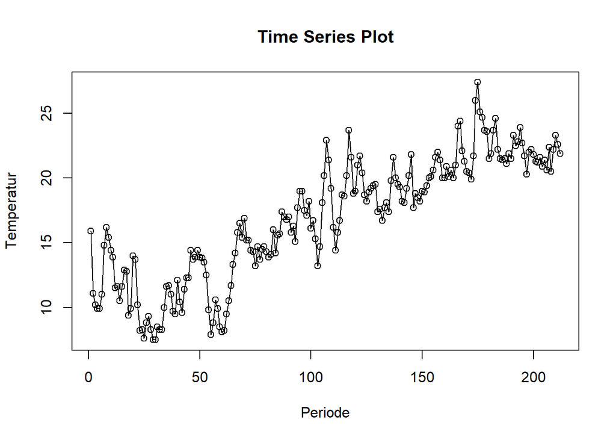

```r
ts.plot(datalat5.ts, xlab="Periode", ylab="Temperatur",
        main = "Time Series Plot")
points(datalat5.ts)
```

```r
mean(datalat5.ts)
```

```
## [1] 16.825
```

```r
var(datalat5.ts)
```

```
## [1] 22.60283
```

Berdasarkan plot time series tersebut, terlihat bahwa data tidak stasioner dalam rataan, ditandai dengan adanya trend pada data dan tidak stasioner dalam ragam, ditandai dengan adanya perbedaan lebar pita pada plot.

### Plot ACF

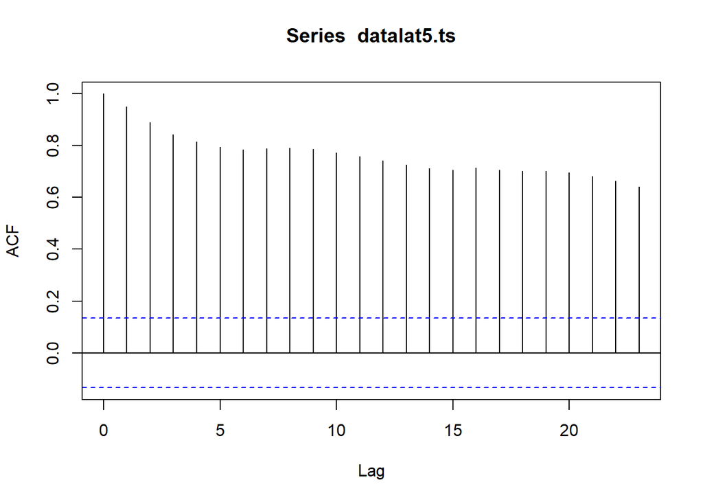

```r
acf(datalat5.ts)
```

Berdasarkan plot ACF, terlihat bahwa plot ACF pada data tersebut menurun secara perlahan (*tails off slowly*) yang menandakan data tidak stasioner dalam rataan.

### Uji ADF

```r
tseries::adf.test(datalat5.ts)
```

```
##
##  Augmented Dickey-Fuller Test
##
## data:  datalat5.ts
## Dickey-Fuller = -3.7167, Lag order = 5, p-value = 0.02419
## alternative hypothesis: stationary
```

$H_0$ : Data tidak stasioner dalam rataan $H_1$ : Data stasioner dalam rataan

Berdasarkan uji ADF tersebut, didapat *p-value* sebesar 0.02419 yang lebih kecil dari taraf nyata 5% sehingga tolak $H_0$ dan menandakan bahwa data stasioner dalam rataan. Hal ini tidak sesuai dengan hasil eksplorasi menggunakan plot time series.

### Plot Box-Cox

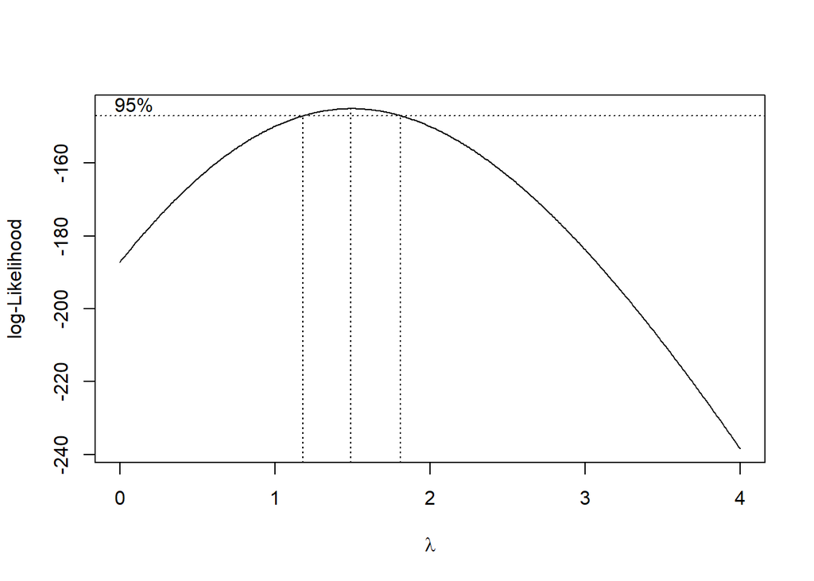

```r
index <- seq(1:212)
bc = boxcox(datalat5.ts~index, lambda = seq(0,4,by=0.01))
```

```r
#Nilai Rounded Lambda
lambda <- bc$x[which.max(bc$y)]
lambda
```

```
## [1] 1.49
```

```r
#SK
bc$x[bc$y > max(bc$y) - 1/2 * qchisq(.95,1)]
```

```
##  [1] 1.19 1.20 1.21 1.22 1.23 1.24 1.25 1.26 1.27 1.28 1.29 1.30 1.31 1.32 1.33
## [16] 1.34 1.35 1.36 1.37 1.38 1.39 1.40 1.41 1.42 1.43 1.44 1.45 1.46 1.47 1.48
## [31] 1.49 1.50 1.51 1.52 1.53 1.54 1.55 1.56 1.57 1.58 1.59 1.60 1.61 1.62 1.63
## [46] 1.64 1.65 1.66 1.67 1.68 1.69 1.70 1.71 1.72 1.73 1.74 1.75 1.76 1.77 1.78
## [61] 1.79 1.80
```

Gambar di atas menunjukkan nilai *rounded value* ($\lambda$) optimum sebesar **1.49** dan pada selang kepercayaan 95% nilai memiliki batas bawah **1.19** dan batas atas **1.80**. Selang tersebut tidak memuat nilai satu sehingga dapat dikatakan bahwa data temperatur tidak stasioner dalam ragam.

### Partisi Data

#### Bagian 1

```r
dt_stas1 <- datalat5.ts[1:104] |> ts()
mean(dt_stas1)
```

```
## [1] 12.81058
```

```r
var(dt_stas1)
```

```
## [1] 9.282314
```

#### Plot Time Series

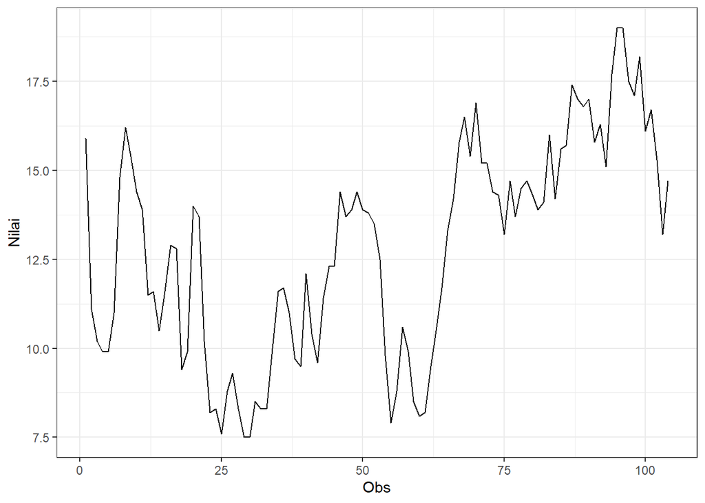

```r
dt_stas1 |> as_tsibble() |>
  ggplot(aes(x = index, y = value)) +
  geom_line() + theme_bw() +
  xlab("Obs") + ylab("Nilai")
```

Berdasarkan plot time series tersebut, terlihat bahwa data partisi bagian pertama tidak stasioner dalam rataan karena masih terdapat tren pada data dan tidak stasioner dalam ragam, ditandai dengan adanya perbedaan lebar pita pada plot.

#### Plot ACF

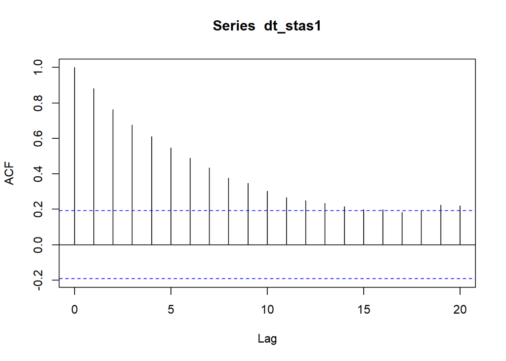

```r
acf(dt_stas1)
```

Berdasarkan plot ACF, terlihat bahwa plot ACF pada data tersebut menurun secara perlahan (*tails off slowly*) yang menandakan data partisi bagian pertama tidak stasioner dalam rataan

#### Uji ADF

```r
tseries::adf.test(dt_stas1)
```

```
##
##  Augmented Dickey-Fuller Test
##
## data:  dt_stas1
## Dickey-Fuller = -2.6979, Lag order = 4, p-value = 0.2873
## alternative hypothesis: stationary
```

$H_0$ : Data tidak stasioner dalam rataan

$H_1$ : Data stasioner dalam rataan

Berdasarkan uji ADF tersebut, didapat *p-value* sebesar 0.2873 yang lebih besar dari taraf nyata 5% sehingga tidak tolak $H_0$ dan menandakan bahwa data partisi bagian pertama tidak stasioner dalam rataan. Hal ini sesuai dengan hasil eksplorasi menggunakan plot time series dan plot ACF.

#### Plot Boxcox

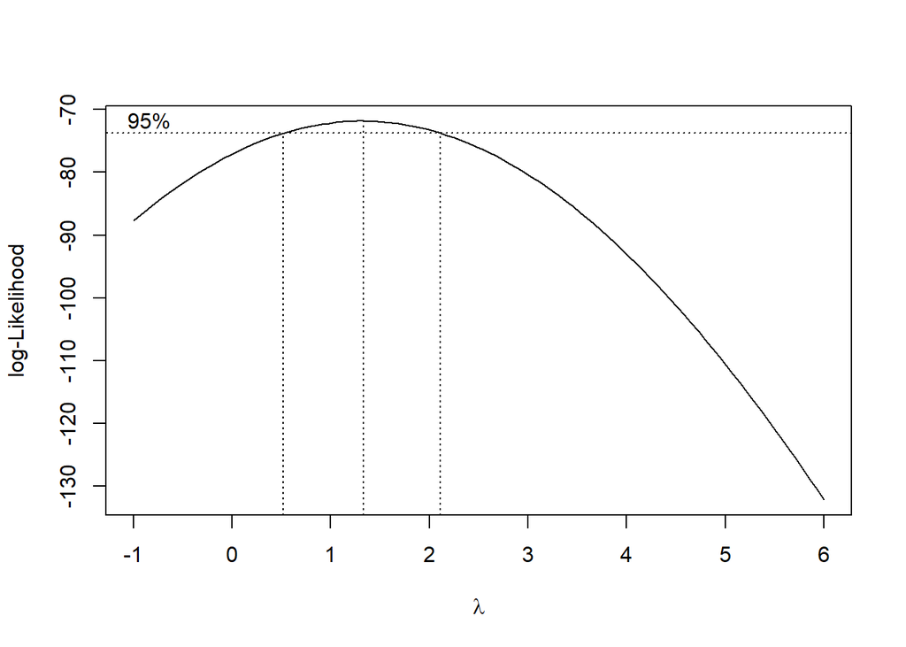

```r
index <- seq(1:104)
bc = boxcox(dt_stas1~index, lambda = seq(-1,6,by=1))
```

```r
#Nilai Rounded Lambda
lambda <- bc$x[which.max(bc$y)]
lambda
```

```
## [1] 1.333333
```

```r
#SK
bc$x[bc$y > max(bc$y) - 1/2 * qchisq(.95,1)]
```

```
##  [1] 0.5555556 0.6262626 0.6969697 0.7676768 0.8383838 0.9090909 0.9797980
##  [8] 1.0505051 1.1212121 1.1919192 1.2626263 1.3333333 1.4040404 1.4747475
## [15] 1.5454545 1.6161616 1.6868687 1.7575758 1.8282828 1.8989899 1.9696970
## [22] 2.0404040 2.1111111
```

#### Bagian 2

```r
dt_stas2 <- datalat5.ts[105:212] |> ts()
mean(dt_stas2)
```

```
## [1] 20.69074
```

```r
var(dt_stas2)
```

```
## [1] 4.889259
```

#### Plot Time Series

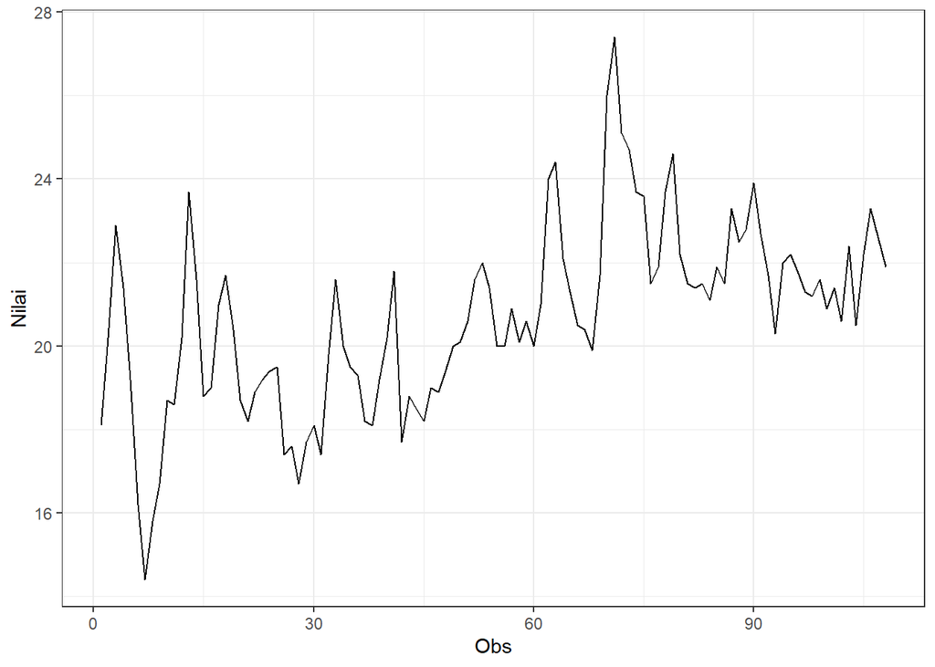

```r
dt_stas2 |> as_tsibble() |>
  ggplot(aes(x = index, y = value)) +
  geom_line() + theme_bw() +
  xlab("Obs") + ylab("Nilai")
```

Berdasarkan plot time series tersebut, terlihat bahwa data partisi bagian kedua tidak stasioner dalam rataan karena masih terdapat tren pada data dan tidak stasioner dalam ragam, ditandai dengan adanya perbedaan lebar pita pada plot.

#### Plot ACF

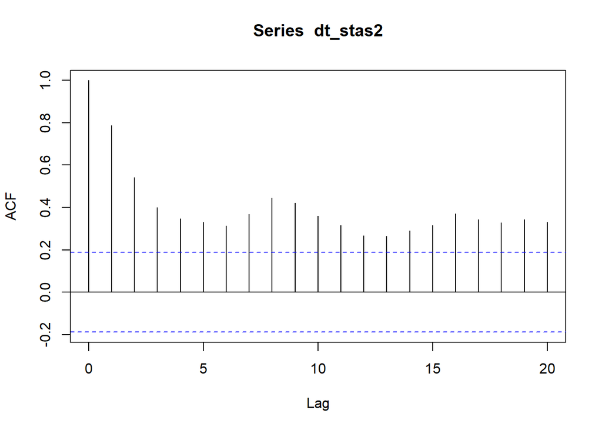

```r
acf(dt_stas2)
```

Berdasarkan plot ACF, terlihat bahwa plot ACF pada data tersebut menurun secara perlahan (*tails off slowly*) yang menandakan data partisi bagian kedua tidak stasioner dalam rataan.

#### Uji ADF

```r
adf.test(dt_stas2)
```

```
##
##  Augmented Dickey-Fuller Test
##
## data:  dt_stas2
## Dickey-Fuller = -3.9523, Lag order = 4, p-value = 0.01414
## alternative hypothesis: stationary
```

$H_0$ : Data tidak stasioner dalam rataan

$H_1$ : Data stasioner dalam rataan

Berdasarkan uji ADF tersebut, didapat *p-value* sebesar 0.01414 yang lebih kecil dari taraf nyata 5% sehingga tolak $H_0$ dan menandakan bahwa data partisi bagian kedua stasioner dalam rataan. Hal ini tidak sesuai dengan hasil eksplorasi menggunakan plot time series dan plot ACF.

#### Plot Boxcox

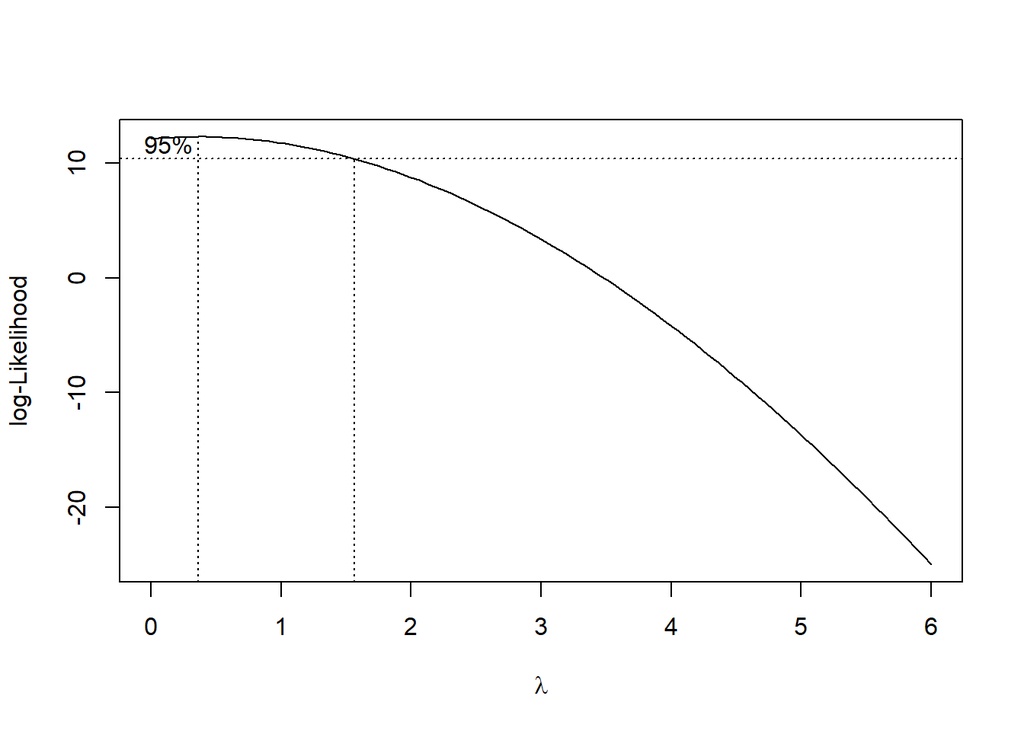

```r
index <- seq(105:212)
bc = boxcox(dt_stas2~index, lambda = seq(0,6,by=1))
```

```r
#Nilai Rounded Lambda
lambda <- bc$x[which.max(bc$y)]
lambda
```

```
## [1] 0.3636364
```

```r
#SK
bc$x[bc$y > max(bc$y) - 1/2 * qchisq(.95,1)]
```

```
##  [1] 0.00000000 0.06060606 0.12121212 0.18181818 0.24242424 0.30303030
##  [7] 0.36363636 0.42424242 0.48484848 0.54545455 0.60606061 0.66666667
## [13] 0.72727273 0.78787879 0.84848485 0.90909091 0.96969697 1.03030303
## [19] 1.09090909 1.15151515 1.21212121 1.27272727 1.33333333 1.39393939
## [25] 1.45454545 1.51515152
```

Gambar di atas menunjukkan nilai *rounded value* ($\lambda$) optimum sebesar **0.36** dan pada selang kepercayaan 95% nilai memiliki batas bawah **0.00** dan batas atas **1.52**. Selang tersebut memuat nilai satu sehingga dapat dikatakan bahwa data partisi bagian kedua stasioner dalam ragam.